```python
import pandas as pd
import numpy as np
```

# Investigating the WA Dataset

## Import data and clean up

```python
WA_raw = pd.read_excel("2021-Waste-Generation-and-Recovery-Data.xlsx", sheet_name =0, header = 3, index_col = 1)
```

```python
WA_raw
```

|  | Unnamed: 0 | Unnamed: 2 | 2000 | 2001 | 2002 | 2003 | 2004 | 2005 | 2006 | 2007 | ... | 2015 | 2016 | 2017 | 2018 | 2019 | 2020 | 2021 | Unnamed: 25 | Unnamed: 26 | Unnamed: 27 |
| --- | --- | --- | --- | --- | --- | --- | --- | --- | --- | --- | --- | --- | --- | --- | --- | --- | --- | --- | --- | --- | --- |
| Category | NaN | Materials Collected for Recycling (tons): | NaN | NaN | NaN | NaN | NaN | NaN | NaN | NaN | ... | NaN | NaN | NaN | NaN | NaN | NaN | NaN | NaN | NaN | NaN |
| C&D | NaN | Ash, Sand & Dust | 10000.0 | 12333.00 | 290.00 | 10576.20 | 40409.0 | 1.458778e+04 | 4.008260e+03 | 2.520990e+03 | ... | 0.000000e+00 | 0.000000e+00 | 0.00 | 0.000 | NaN | NaN | 0.00 | NaN | NaN | NaN |
| C&D | NaN | Asphalt & Concrete | 893218.0 | 1116870.96 | 1451958.69 | 1600288.21 | 2002171.0 | 1.783418e+06 | 2.295278e+06 | 2.089972e+06 | ... | 2.109809e+06 | 2.387249e+06 | 2736135.90 | 2998371.946 | NaN | NaN | 2791859.54 | NaN | NaN | NaN |
| C&D | NaN | Carpet & Pad | 97.1 | 819.54 | 148.49 | 257.58 | 304.0 | 1.860300e+02 | 8.965900e+02 | 1.193378e+03 | ... | 2.312580e+03 | 2.114270e+03 | 3141.10 | 2109.210 | NaN | NaN | 319.00 | NaN | NaN | NaN |
| C&D | NaN | Construction & Demolition Debris | 376683.5 | 131921.78 | 131700.57 | 143844.31 | 166325.0 | 5.210867e+05 | 3.008197e+05 | 3.020893e+05 | ... | 4.644028e+05 | 4.378577e+05 | 434196.65 | 596109.770 | NaN | NaN | 713716.73 | NaN | NaN | NaN |
| ... | ... | ... | ... | ... | ... | ... | ... | ... | ... | ... | ... | ... | ... | ... | ... | ... | ... | ... | ... | ... | ... |
| Other | NaN | Clothing & Household items reused | 524.0 | 600.80 | 79.06 | 918.43 | 738.0 | 2.891420e+03 | 8.044000e+02 | 4.346390e+03 | ... | 7.659480e+03 | 1.924868e+04 | 15282.71 | 1793.740 | NaN | NaN | 585.86 | NaN | NaN | NaN |
| Other | NaN | Miscellaneous reused | 198.0 | 334.07 | 309.53 | 7488.07 | 521.0 | 4.350000e+02 | 6.270000e+02 | 2.860000e+02 | ... | 0.000000e+00 | 0.000000e+00 | 0.00 | 3654.860 | NaN | NaN | 20947.22 | NaN | NaN | NaN |
| Other | NaN | Appliances for reuse | NaN | NaN | NaN | NaN | NaN | NaN | NaN | NaN | ... | NaN | NaN | NaN | NaN | NaN | NaN | 85.00 | NaN | NaN | NaN |
| Other | NaN | Tires retreaded and/or reused | 0.0 | 1009.00 | 1170.00 | 12976.22 | 251.0 | 4.088500e+03 | 1.326550e+04 | 4.764090e+03 | ... | 6.759460e+03 | 4.527261e+03 | 5363.62 | 7045.640 | NaN | NaN | 2691.13 | NaN | NaN | NaN |
| Total Reused Materials Reported | NaN | NaN | 2019.0 | 4005.47 | 78621.22 | 33698.25 | 8051.0 | 1.025632e+04 | 1.686796e+04 | 1.111448e+04 | ... | 2.273017e+04 | 4.250476e+04 | 32330.16 | 17545.290 | 0.0 | 0.0 | 266534.90 | NaN | NaN | NaN |

97 rows × 27 columns

#### Unfortunately, only the recycling data is broken into categories, not the entire dataset. I have recycling data in categories and the rest of the garbage is accounted for in one number. The dataset does include the population of WA state by year. I'm going to change the total garbage amount to a per capita amount and see if there's any correlation to shifted unemployment rates.

```python
WA_SWG = WA_raw.loc[['Solid Waste Generated (recoverable & non-recoverable)','Population']].transpose()
WA_SWG = WA_SWG.iloc[2:-6]
WA_SWG.head()
```

|  | Solid Waste Generated (recoverable & non-recoverable) | Population |
| --- | --- | --- |
| 2000 | 11010803.91 | 5894143.0 |
| 2001 | 11712978.94 | 5970452.0 |
| 2002 | 12263995.43 | 6059698.0 |
| 2003 | 12670189.08 | 6126917.0 |
| 2004 | 15309438.0 | 6208532.0 |

```python
WA_PerCapita = pd.DataFrame({"SWG per Person": pd.to_numeric(WA_SWG['Solid Waste Generated (recoverable & non-recoverable)'] / WA_SWG['Population'])})
WA_PerCapita.head()
```

|  | SWG per Person |
| --- | --- |
| 2000 | 1.868092 |
| 2001 | 1.961824 |
| 2002 | 2.023862 |
| 2003 | 2.067955 |
| 2004 | 2.465871 |

Read in WA unemployment rate data. This is reported by month. I'll take an average of the monthly rate to create a yearly rate.

```python
unemployment_raw = pd.read_excel('WAUnemployment.xlsx', header=10)
unemployment_raw.head()
```

|  | Year | Jan | Feb | Mar | Apr | May | Jun | Jul | Aug | Sep | Oct | Nov | Dec |
| --- | --- | --- | --- | --- | --- | --- | --- | --- | --- | --- | --- | --- | --- |
| 0 | 2000 | 4.8 | 4.9 | 4.9 | 5.0 | 5.1 | 5.1 | 5.2 | 5.2 | 5.2 | 5.2 | 5.2 | 5.3 |
| 1 | 2001 | 5.4 | 5.5 | 5.6 | 5.7 | 5.7 | 5.8 | 5.9 | 6.1 | 6.3 | 6.5 | 6.7 | 6.9 |
| 2 | 2002 | 7.0 | 7.1 | 7.1 | 7.1 | 7.1 | 7.1 | 7.0 | 7.0 | 7.0 | 7.1 | 7.1 | 7.2 |
| 3 | 2003 | 7.2 | 7.3 | 7.3 | 7.3 | 7.4 | 7.4 | 7.4 | 7.3 | 7.2 | 7.1 | 7.0 | 6.9 |
| 4 | 2004 | 6.8 | 6.7 | 6.6 | 6.5 | 6.4 | 6.3 | 6.2 | 6.1 | 6.1 | 6.0 | 6.0 | 5.9 |

```python
unemployment = unemployment_raw.copy()
unemployment = unemployment.set_index('Year')
unemployment['Mean'] = unemployment.mean(axis=1)
```

I'm more interested in knowing if there's a correlation between the amount of garbage produced per capita and the change in unemployment (is the unemployment rate going up or down?). I'm going to derive a feature to mark a time period as 0 for "the unemployment rate has decreased compared to last year" and 1: "the unemployment rate has increased since last year".

```python
unemployment_diff = unemployment['Mean'].diff()
unemployment['Rate_Change'] = unemployment_diff.apply(lambda x: 1 if x > 0 else 0)
```

```python
unemployment
```

| Year | Jan | Feb | Mar | Apr | May | Jun | Jul | Aug | Sep | Oct | Nov | Dec | Mean | Rate_Change |
| --- | --- | --- | --- | --- | --- | --- | --- | --- | --- | --- | --- | --- | --- | --- |
| 2000 | 4.8 | 4.9 | 4.9 | 5.0 | 5.1 | 5.1 | 5.2 | 5.2 | 5.2 | 5.2 | 5.2 | 5.3 | 5.091667 | 0 |
| 2001 | 5.4 | 5.5 | 5.6 | 5.7 | 5.7 | 5.8 | 5.9 | 6.1 | 6.3 | 6.5 | 6.7 | 6.9 | 6.008333 | 1 |
| 2002 | 7.0 | 7.1 | 7.1 | 7.1 | 7.1 | 7.1 | 7.0 | 7.0 | 7.0 | 7.1 | 7.1 | 7.2 | 7.075000 | 1 |
| 2003 | 7.2 | 7.3 | 7.3 | 7.3 | 7.4 | 7.4 | 7.4 | 7.3 | 7.2 | 7.1 | 7.0 | 6.9 | 7.233333 | 1 |
| 2004 | 6.8 | 6.7 | 6.6 | 6.5 | 6.4 | 6.3 | 6.2 | 6.1 | 6.1 | 6.0 | 6.0 | 5.9 | 6.300000 | 0 |
| 2005 | 5.9 | 5.9 | 5.8 | 5.7 | 5.6 | 5.6 | 5.6 | 5.6 | 5.5 | 5.4 | 5.3 | 5.2 | 5.591667 | 0 |
| 2006 | 5.1 | 5.0 | 5.0 | 5.0 | 5.0 | 5.1 | 5.1 | 5.0 | 5.0 | 5.0 | 4.9 | 4.8 | 5.000000 | 0 |
| 2007 | 4.7 | 4.6 | 4.5 | 4.5 | 4.5 | 4.5 | 4.6 | 4.6 | 4.7 | 4.7 | 4.7 | 4.6 | 4.600000 | 0 |
| 2008 | 4.6 | 4.6 | 4.7 | 4.8 | 5.0 | 5.2 | 5.3 | 5.4 | 5.6 | 5.8 | 6.1 | 6.4 | 5.291667 | 1 |
| 2009 | 6.8 | 7.2 | 7.5 | 7.8 | 8.1 | 8.3 | 8.5 | 8.7 | 9.0 | 9.0 | 9.1 | 9.2 | 8.266667 | 1 |
| 2010 | 9.3 | 9.3 | 9.3 | 9.2 | 9.1 | 9.0 | 9.0 | 9.1 | 9.1 | 9.1 | 9.1 | 9.0 | 9.133333 | 1 |
| 2011 | 8.9 | 8.8 | 8.8 | 8.7 | 8.6 | 8.6 | 8.6 | 8.5 | 8.4 | 8.3 | 8.1 | 8.0 | 8.525000 | 0 |
| 2012 | 8.0 | 7.9 | 7.9 | 7.9 | 8.0 | 8.0 | 7.8 | 7.6 | 7.4 | 7.2 | 7.1 | 6.9 | 7.641667 | 0 |
| 2013 | 6.9 | 6.7 | 6.7 | 6.7 | 6.7 | 6.7 | 6.7 | 6.7 | 6.6 | 6.5 | 6.4 | 6.3 | 6.633333 | 0 |
| 2014 | 6.2 | 6.1 | 6.1 | 6.0 | 6.0 | 5.9 | 5.9 | 5.9 | 5.8 | 5.8 | 5.7 | 5.7 | 5.925000 | 0 |
| 2015 | 5.6 | 5.5 | 5.5 | 5.4 | 5.4 | 5.4 | 5.4 | 5.4 | 5.4 | 5.4 | 5.4 | 5.4 | 5.433333 | 0 |
| 2016 | 5.4 | 5.4 | 5.4 | 5.3 | 5.3 | 5.3 | 5.3 | 5.2 | 5.1 | 5.1 | 5.0 | 4.9 | 5.225000 | 0 |
| 2017 | 4.8 | 4.7 | 4.6 | 4.6 | 4.6 | 4.6 | 4.6 | 4.6 | 4.7 | 4.7 | 4.6 | 4.6 | 4.641667 | 0 |
| 2018 | 4.6 | 4.6 | 4.5 | 4.4 | 4.3 | 4.3 | 4.3 | 4.3 | 4.3 | 4.4 | 4.5 | 4.6 | 4.425000 | 0 |
| 2019 | 4.7 | 4.6 | 4.6 | 4.4 | 4.3 | 4.2 | 4.1 | 4.1 | 4.1 | 4.0 | 3.9 | 3.8 | 4.233333 | 0 |
| 2020 | 3.8 | 3.8 | 5.2 | 16.6 | 13.2 | 11.3 | 10.2 | 8.7 | 8.0 | 7.2 | 6.8 | 6.6 | 8.450000 | 1 |
| 2021 | 6.3 | 6.1 | 5.9 | 5.7 | 5.4 | 5.3 | 5.1 | 5.0 | 4.8 | 4.5 | 4.3 | 4.1 | 5.208333 | 0 |
| 2022 | 4.0 | 4.0 | 3.9 | 3.9 | 3.9 | 3.9 | 4.1 | 4.3 | 4.4 | 4.6 | 4.6 | 4.5 | 4.175000 | 0 |
| 2023 | 4.6 | 4.6 | 4.5 | 4.3 | 4.1 | 3.8 | 3.6 | 3.6 | 3.6 | NaN | NaN | NaN | 4.077778 | 0 |

```python
WA2 = pd.concat([WA_PerCapita, unemployment[['Rate_Change', 'Mean']]], axis=1)
```

```python
WA2
```

|  | SWG per Person | Rate_Change | Mean |
| --- | --- | --- | --- |
| 2000 | 1.868092 | 0 | 5.091667 |
| 2001 | 1.961824 | 1 | 6.008333 |
| 2002 | 2.023862 | 1 | 7.075000 |
| 2003 | 2.067955 | 1 | 7.233333 |
| 2004 | 2.465871 | 0 | 6.300000 |
| 2005 | 2.776682 | 0 | 5.591667 |
| 2006 | 2.666581 | 0 | 5.000000 |
| 2007 | 2.631629 | 0 | 4.600000 |
| 2008 | 2.413254 | 1 | 5.291667 |
| 2009 | 2.263308 | 1 | 8.266667 |
| 2010 | 2.453214 | 1 | 9.133333 |
| 2011 | 2.352099 | 0 | 8.525000 |
| 2012 | 2.327073 | 0 | 7.641667 |
| 2013 | 2.450666 | 0 | 6.633333 |
| 2014 | 2.481429 | 0 | 5.925000 |
| 2015 | 2.485185 | 0 | 5.433333 |
| 2016 | 2.522604 | 0 | 5.225000 |
| 2017 | 2.548879 | 0 | 4.641667 |
| 2018 | 2.541191 | 0 | 4.425000 |
| 2019 | NaN | 0 | 4.233333 |
| 2020 | NaN | 1 | 8.450000 |
| 2021 | NaN | 0 | 5.208333 |
| 2022 | NaN | 0 | 4.175000 |
| 2023 | NaN | 0 | 4.077778 |

For forecasting purposes, I will need to shift my economic data. I'll first try shifting it 2 years and check for any correlation.

```python
WA2['Rate_Change_Shifted'] = WA2['Rate_Change'].shift(-2)
WA2['Mean_Shifted'] = WA2['Mean'].shift(-2)
```

```python
WA2 = WA2.iloc[:-5]
WA2
```

|  | SWG per Person | Rate_Change | Mean | Rate_Change_Shifted | Mean_Shifted |
| --- | --- | --- | --- | --- | --- |
| 2000 | 1.868092 | 0 | 5.091667 | 1.0 | 7.075000 |
| 2001 | 1.961824 | 1 | 6.008333 | 1.0 | 7.233333 |
| 2002 | 2.023862 | 1 | 7.075000 | 0.0 | 6.300000 |
| 2003 | 2.067955 | 1 | 7.233333 | 0.0 | 5.591667 |
| 2004 | 2.465871 | 0 | 6.300000 | 0.0 | 5.000000 |
| 2005 | 2.776682 | 0 | 5.591667 | 0.0 | 4.600000 |
| 2006 | 2.666581 | 0 | 5.000000 | 1.0 | 5.291667 |
| 2007 | 2.631629 | 0 | 4.600000 | 1.0 | 8.266667 |
| 2008 | 2.413254 | 1 | 5.291667 | 1.0 | 9.133333 |
| 2009 | 2.263308 | 1 | 8.266667 | 0.0 | 8.525000 |
| 2010 | 2.453214 | 1 | 9.133333 | 0.0 | 7.641667 |
| 2011 | 2.352099 | 0 | 8.525000 | 0.0 | 6.633333 |
| 2012 | 2.327073 | 0 | 7.641667 | 0.0 | 5.925000 |
| 2013 | 2.450666 | 0 | 6.633333 | 0.0 | 5.433333 |
| 2014 | 2.481429 | 0 | 5.925000 | 0.0 | 5.225000 |
| 2015 | 2.485185 | 0 | 5.433333 | 0.0 | 4.641667 |
| 2016 | 2.522604 | 0 | 5.225000 | 0.0 | 4.425000 |
| 2017 | 2.548879 | 0 | 4.641667 | 0.0 | 4.233333 |
| 2018 | 2.541191 | 0 | 4.425000 | 1.0 | 8.450000 |

```python
print(f'Rate Change Corr: {WA2["SWG per Person"].corr(WA2["Rate_Change_Shifted"])}')
print(f'Mean Correlation: {WA2["SWG per Person"].corr(WA2["Mean_Shifted"])}')
```

```
Rate Change Corr: -0.10520277847677122
Mean Correlation: -0.26306654950838104
```

There is little to no correlation between the unemployment rate and the per capital amount of garbage generated.

Try shifting the economic data 1 year and check for any correlation.

```python
WA1 = pd.concat([WA_PerCapita, unemployment[['Rate_Change', 'Mean']]], axis=1)
WA1['Rate_Change_Shifted'] = WA1['Rate_Change'].shift(-1)
WA1['Mean_Shifted'] = WA1['Mean'].shift(-1)
WA1
```

|  | SWG per Person | Rate_Change | Mean | Rate_Change_Shifted | Mean_Shifted |
| --- | --- | --- | --- | --- | --- |
| 2000 | 1.868092 | 0 | 5.091667 | 1.0 | 6.008333 |
| 2001 | 1.961824 | 1 | 6.008333 | 1.0 | 7.075000 |
| 2002 | 2.023862 | 1 | 7.075000 | 1.0 | 7.233333 |
| 2003 | 2.067955 | 1 | 7.233333 | 0.0 | 6.300000 |
| 2004 | 2.465871 | 0 | 6.300000 | 0.0 | 5.591667 |
| 2005 | 2.776682 | 0 | 5.591667 | 0.0 | 5.000000 |
| 2006 | 2.666581 | 0 | 5.000000 | 0.0 | 4.600000 |
| 2007 | 2.631629 | 0 | 4.600000 | 1.0 | 5.291667 |
| 2008 | 2.413254 | 1 | 5.291667 | 1.0 | 8.266667 |
| 2009 | 2.263308 | 1 | 8.266667 | 1.0 | 9.133333 |
| 2010 | 2.453214 | 1 | 9.133333 | 0.0 | 8.525000 |
| 2011 | 2.352099 | 0 | 8.525000 | 0.0 | 7.641667 |
| 2012 | 2.327073 | 0 | 7.641667 | 0.0 | 6.633333 |
| 2013 | 2.450666 | 0 | 6.633333 | 0.0 | 5.925000 |
| 2014 | 2.481429 | 0 | 5.925000 | 0.0 | 5.433333 |
| 2015 | 2.485185 | 0 | 5.433333 | 0.0 | 5.225000 |
| 2016 | 2.522604 | 0 | 5.225000 | 0.0 | 4.641667 |
| 2017 | 2.548879 | 0 | 4.641667 | 0.0 | 4.425000 |
| 2018 | 2.541191 | 0 | 4.425000 | 0.0 | 4.233333 |
| 2019 | NaN | 0 | 4.233333 | 1.0 | 8.450000 |
| 2020 | NaN | 1 | 8.450000 | 0.0 | 5.208333 |
| 2021 | NaN | 0 | 5.208333 | 0.0 | 4.175000 |
| 2022 | NaN | 0 | 4.175000 | 0.0 | 4.077778 |
| 2023 | NaN | 0 | 4.077778 | NaN | NaN |

```python
WA1 = WA1.iloc[:-5]
WA1
```

|  | SWG per Person | Rate_Change | Mean | Rate_Change_Shifted | Mean_Shifted |
| --- | --- | --- | --- | --- | --- |
| 2000 | 1.868092 | 0 | 5.091667 | 1.0 | 6.008333 |
| 2001 | 1.961824 | 1 | 6.008333 | 1.0 | 7.075000 |
| 2002 | 2.023862 | 1 | 7.075000 | 1.0 | 7.233333 |
| 2003 | 2.067955 | 1 | 7.233333 | 0.0 | 6.300000 |
| 2004 | 2.465871 | 0 | 6.300000 | 0.0 | 5.591667 |
| 2005 | 2.776682 | 0 | 5.591667 | 0.0 | 5.000000 |
| 2006 | 2.666581 | 0 | 5.000000 | 0.0 | 4.600000 |
| 2007 | 2.631629 | 0 | 4.600000 | 1.0 | 5.291667 |
| 2008 | 2.413254 | 1 | 5.291667 | 1.0 | 8.266667 |
| 2009 | 2.263308 | 1 | 8.266667 | 1.0 | 9.133333 |
| 2010 | 2.453214 | 1 | 9.133333 | 0.0 | 8.525000 |
| 2011 | 2.352099 | 0 | 8.525000 | 0.0 | 7.641667 |
| 2012 | 2.327073 | 0 | 7.641667 | 0.0 | 6.633333 |
| 2013 | 2.450666 | 0 | 6.633333 | 0.0 | 5.925000 |
| 2014 | 2.481429 | 0 | 5.925000 | 0.0 | 5.433333 |
| 2015 | 2.485185 | 0 | 5.433333 | 0.0 | 5.225000 |
| 2016 | 2.522604 | 0 | 5.225000 | 0.0 | 4.641667 |
| 2017 | 2.548879 | 0 | 4.641667 | 0.0 | 4.425000 |
| 2018 | 2.541191 | 0 | 4.425000 | 0.0 | 4.233333 |

```python
print(f'Rate Change Corr: {WA1["SWG per Person"].corr(WA1["Rate_Change_Shifted"])}')
print(f'Mean Correlation: {WA1["SWG per Person"].corr(WA1["Mean_Shifted"])}')
```

```
Rate Change Corr: -0.5392485768072074
Mean Correlation: -0.4739516221161371
```

```python
import matplotlib.pyplot as plt
```

```python
WA1
```

|  | SWG per Person | Rate_Change | Mean | Rate_Change_Shifted | Mean_Shifted |
| --- | --- | --- | --- | --- | --- |
| 2000 | 1.868092 | 0 | 5.091667 | 1.0 | 6.008333 |
| 2001 | 1.961824 | 1 | 6.008333 | 1.0 | 7.075000 |
| 2002 | 2.023862 | 1 | 7.075000 | 1.0 | 7.233333 |
| 2003 | 2.067955 | 1 | 7.233333 | 0.0 | 6.300000 |
| 2004 | 2.465871 | 0 | 6.300000 | 0.0 | 5.591667 |
| 2005 | 2.776682 | 0 | 5.591667 | 0.0 | 5.000000 |
| 2006 | 2.666581 | 0 | 5.000000 | 0.0 | 4.600000 |
| 2007 | 2.631629 | 0 | 4.600000 | 1.0 | 5.291667 |
| 2008 | 2.413254 | 1 | 5.291667 | 1.0 | 8.266667 |
| 2009 | 2.263308 | 1 | 8.266667 | 1.0 | 9.133333 |
| 2010 | 2.453214 | 1 | 9.133333 | 0.0 | 8.525000 |
| 2011 | 2.352099 | 0 | 8.525000 | 0.0 | 7.641667 |
| 2012 | 2.327073 | 0 | 7.641667 | 0.0 | 6.633333 |
| 2013 | 2.450666 | 0 | 6.633333 | 0.0 | 5.925000 |
| 2014 | 2.481429 | 0 | 5.925000 | 0.0 | 5.433333 |
| 2015 | 2.485185 | 0 | 5.433333 | 0.0 | 5.225000 |
| 2016 | 2.522604 | 0 | 5.225000 | 0.0 | 4.641667 |
| 2017 | 2.548879 | 0 | 4.641667 | 0.0 | 4.425000 |
| 2018 | 2.541191 | 0 | 4.425000 | 0.0 | 4.233333 |

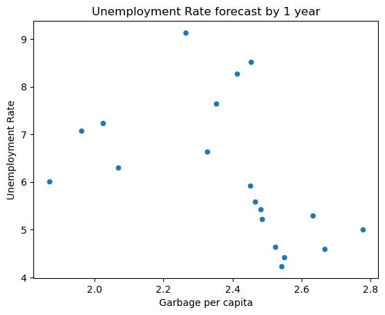

```python
df = pd.DataFrame({'Garbage per capita': WA1['SWG per Person'], 'Unemployment Rate': WA1['Mean_Shifted']})
df.plot.scatter('Garbage per capita', 'Unemployment Rate')
plt.title("Unemployment Rate forecast by 1 year")
plt.savefig("WADataScatter.png")
plt.show()
```